# ES207_Homework8

Anshika

3/22/2020

```r
library(stringr)
library(dplyr)
library(tidyverse)
library(readr)
library(data.table)
library(readxl)
```

** 14.2.5 Exercises**

**1. In code that doesn’t use stringr, you’ll often see paste() and paste0(). What’s the difference between the two functions? What stringr function are they equivalent to? How do the functions differ in their handling of NA?**

The function paste() and paste0 both “concatenate vectors after converting to character.”

```r
paste1 <- paste("test", "function")
paste2 <- paste0("test", "function")
paste3 <- str_c("test", "function")
paste1
```

```
## [1] "test function"
```

```r
paste2
```

```
## [1] "testfunction"
```

```r
paste3
```

```
## [1] "testfunction"
```

However, as seen from above functions, paste() separates strings by spaces, while paste0() does not separate input variables with spaces.

They are equivalent to “str_c” function and it resembles paste0 function.

```r
#Handling of NA
paste("test", NA)
```

```
## [1] "test NA"
```

```r
paste0("test", NA)
```

```
## [1] "testNA"
```

```r
str_c("test", NA)
```

```
## [1] NA
```

Both paste functions treat NA as string and convert them to characters. But str_c treats it as numeric vector and returns only NA.

**2 In your own words, describe the difference between the sep and collapse arguments to str_c().**

Argument “sep” in str_c is for intersting a string between two input fectors for seaprating them. Whereas, collapse is the string used to separate any elements of the character vector into a character vector of length one.

**3 Use str_length() and str_sub() to extract the middle character from a string. What will you do if the string has an even number of characters?**

```r
str_exm <- c("apple", "banana", "pear", "pineapple")
len <- str_length(str_exm)
mid <- ceiling(len/2)
mid2 <- floor(len/2)
str_sub(str_exm, mid, mid)
```

```
## [1] "p" "n" "e" "a"
```

```r
str_sub(str_exm, mid2, mid2)
```

```
## [1] "p" "n" "e" "e"
```

The functions “cleiling” or “floor” can be useful to extract the middle character. If the string has an even number of characters to select middle character n/2 is used on the str_length.

**4 What does str_wrap() do? When might you want to use it?**

The function str_wrap() wraps strings into formatted paragraphs. This is helpful for wrapping long strings of text to single words.

```r
str_exm1 <- c("The function str_wrap() wraps strings into formatted paragraphs. This is helpful for wrapping long strings of text to single words.")
cat(str_wrap(str_exm1, width = 3, exdent = 2), "\n")
```

```
## The
##   function
##   str_wrap()
##   wraps
##   strings
##   into
##   formatted
##   paragraphs.
##   This
##   is
##   helpful
##   for
##   wrapping
##   long
##   strings
##   of
##   text
##   to
##   single
##   words.
```

**5 What does str_trim() do? What’s the opposite of str_trim()?**

The function str_trim() “removes whitespace from start and end of string.”

```r
str_trim ("   The function str_trim() removes whitespace from start and end of string       ", side = "left")
```

```
## [1] "The function str_trim() removes whitespace from start and end of string       "
```

**6 Write a function that turns (e.g.) a vector c(“a”, “b”, “c”) into the string “a, b, and c”. Think carefully about what it should do if given a vector of length 0, 1, or 2.**

```r
str_commasep <- function(x, delim = ",") {
  n <- length(x)
  if (n == 0) {
    ""
  } else if (n == 1) {
    x
  } else if (n == 2) {
    # no comma before and when n == 2
    str_c(x[[1]], "and", x[[2]], sep = " ")
  } else {
    # commas after all n - 1 elements
    not_last <- str_c(x[seq_len(n - 1)], delim)
    # prepend "and" to the last element
    last <- str_c("and", x[[n]], sep = " ")
    # combine parts with spaces
    str_c(c(not_last, last), collapse = " ")
  }
}
str_commasep("")
```

```
## [1] ""
```

```r
str_commasep("a")
```

```
## [1] "a"
```

```r
str_commasep(c("a", "b"))
```

```
## [1] "a and b"
```

```r
str_commasep(c("a", "b", "c"))
```

```
## [1] "a, b, and c"
```

**14.3.1.1 Exercises**

**3. What patterns will the regular expression ...... match? How would you represent it as a string?**

It will match any patterns that are a dot followed by any character, repeated three times.

```r
str_view(c(".a.b.c", ".a.b", "....."), c("\\..\\..\\.."), match = TRUE)
```

[interactive chart not shown]

**14.3.3.1 Exercises**

**1. Create regular expressions to find all words that:**

1. Start with a vowel.

```r
str_subset(stringr::words, "^[aeiou]")
```

```
##   [1] "a"           "able"        "about"       "absolute"    "accept"
##   [6] "account"     "achieve"     "across"      "act"         "active"
##  [11] "actual"      "add"         "address"     "admit"       "advertise"
##  [16] "affect"      "afford"      "after"       "afternoon"   "again"
##  [21] "against"     "age"         "agent"       "ago"         "agree"
##  [26] "air"         "all"         "allow"       "almost"      "along"
##  [31] "already"     "alright"     "also"        "although"    "always"
##  [36] "america"     "amount"      "and"         "another"     "answer"
##  [41] "any"         "apart"       "apparent"    "appear"      "apply"
##  [46] "appoint"     "approach"    "appropriate" "area"        "argue"
##  [51] "arm"         "around"      "arrange"     "art"         "as"
##  [56] "ask"         "associate"   "assume"      "at"          "attend"
##  [61] "authority"   "available"   "aware"       "away"        "awful"
##  [66] "each"        "early"       "east"        "easy"        "eat"
##  [71] "economy"     "educate"     "effect"      "egg"         "eight"
```

[output cut: 20 more lines]

2. That only contain consonants. (Hint: thinking about matching “not”-vowels.)

```r
str_subset(stringr::words, "^[^aeiou]+$")
```

```
## [1] "by"  "dry" "fly" "mrs" "try" "why"
```

3. End with ed, but not with eed.

```r
str_subset(stringr::words, "[^e]ed$")
```

```
## [1] "bed"     "hundred" "red"
```

4. End with ing or ise.

```r
str_subset(stringr::words, "i(ng|se)$")
```

```
##  [1] "advertise" "bring"     "during"    "evening"   "exercise"  "king"
##  [7] "meaning"   "morning"   "otherwise" "practise"  "raise"     "realise"
## [13] "ring"      "rise"      "sing"      "surprise"  "thing"
```

**14.3.4.1 Exercises**

**2. Describe in words what these regular expressions match: (read carefully to see if I’m using a regular expression or a string that defines a regular expression.)**

1. ^.*$ = Match any string

ii “\{.+\}” = Any string with curly braces surrounding at least one character.

**14.4.1.1 Exercises**

**1.For each of the following challenges, try solving it by using both a single regular expression, and a combination of multiple str_detect() calls.**

Find all words that start or end with x.

```r
words[str_detect(words, "^x|x$")]
```

```
## [1] "box" "sex" "six" "tax"
```

```r
start_with_x <- str_detect(words, "^x")
end_with_x <- str_detect(words, "x$")
words[start_with_x | end_with_x]
```

```
## [1] "box" "sex" "six" "tax"
```

Find all words that start with a vowel and end with a consonant.

```r
str_subset(words, "^[aeiou].*[^aeiou]$")
```

```
##   [1] "about"       "accept"      "account"     "across"      "act"
##   [6] "actual"      "add"         "address"     "admit"       "affect"
##  [11] "afford"      "after"       "afternoon"   "again"       "against"
##  [16] "agent"       "air"         "all"         "allow"       "almost"
##  [21] "along"       "already"     "alright"     "although"    "always"
##  [26] "amount"      "and"         "another"     "answer"      "any"
##  [31] "apart"       "apparent"    "appear"      "apply"       "appoint"
##  [36] "approach"    "arm"         "around"      "art"         "as"
##  [41] "ask"         "at"          "attend"      "authority"   "away"
##  [46] "awful"       "each"        "early"       "east"        "easy"
##  [51] "eat"         "economy"     "effect"      "egg"         "eight"
##  [56] "either"      "elect"       "electric"    "eleven"      "employ"
##  [61] "end"         "english"     "enjoy"       "enough"      "enter"
##  [66] "environment" "equal"       "especial"    "even"        "evening"
##  [71] "ever"        "every"       "exact"       "except"      "exist"
##  [76] "expect"      "explain"     "express"     "identify"    "if"
##  [81] "important"   "in"          "indeed"      "individual"  "industry"
##  [86] "inform"      "instead"     "interest"    "invest"      "it"
##  [91] "item"        "obvious"     "occasion"    "odd"         "of"
##  [96] "off"         "offer"       "often"       "okay"        "old"
## [101] "on"          "only"        "open"        "opportunity" "or"
## [106] "order"       "original"    "other"       "ought"       "out"
## [111] "over"        "own"         "under"       "understand"  "union"
## [116] "unit"        "university"  "unless"      "until"       "up"
## [121] "upon"        "usual"
```

```r
start_with_vowel <- str_detect(words, "^[aeiou]")
end_with_consonant <- str_detect(words, "[^aeiou]$")
words[start_with_vowel & end_with_consonant]
```

```
##   [1] "about"       "accept"      "account"     "across"      "act"
##   [6] "actual"      "add"         "address"     "admit"       "affect"
##  [11] "afford"      "after"       "afternoon"   "again"       "against"
##  [16] "agent"       "air"         "all"         "allow"       "almost"
##  [21] "along"       "already"     "alright"     "although"    "always"
##  [26] "amount"      "and"         "another"     "answer"      "any"
##  [31] "apart"       "apparent"    "appear"      "apply"       "appoint"
##  [36] "approach"    "arm"         "around"      "art"         "as"
##  [41] "ask"         "at"          "attend"      "authority"   "away"
##  [46] "awful"       "each"        "early"       "east"        "easy"
##  [51] "eat"         "economy"     "effect"      "egg"         "eight"
##  [56] "either"      "elect"       "electric"    "eleven"      "employ"
##  [61] "end"         "english"     "enjoy"       "enough"      "enter"
##  [66] "environment" "equal"       "especial"    "even"        "evening"
##  [71] "ever"        "every"       "exact"       "except"      "exist"
##  [76] "expect"      "explain"     "express"     "identify"    "if"
##  [81] "important"   "in"          "indeed"      "individual"  "industry"
##  [86] "inform"      "instead"     "interest"    "invest"      "it"
##  [91] "item"        "obvious"     "occasion"    "odd"         "of"
##  [96] "off"         "offer"       "often"       "okay"        "old"
## [101] "on"          "only"        "open"        "opportunity" "or"
## [106] "order"       "original"    "other"       "ought"       "out"
## [111] "over"        "own"         "under"       "understand"  "union"
## [116] "unit"        "university"  "unless"      "until"       "up"
## [121] "upon"        "usual"
```

Are there any words that contain at least one of each different vowel?

```r
words[str_detect(words, "a") &
        str_detect(words, "e") &
        str_detect(words, "i") &
        str_detect(words, "o") &
        str_detect(words, "u")]
```

```
## character(0)
```

What word has the highest number of vowels? What word has the highest proportion of vowels? (Hint: what is the denominator?)

```r
#Highest ni. of vowel
vowels <- str_count(words, "[aeiou]")
words[which(vowels == max(vowels))]
```

```
## [1] "appropriate" "associate"   "available"   "colleague"   "encourage"
## [6] "experience"  "individual"  "television"
```

```r
#Highest proportion of vowel
prop_vowels <- str_count(words, "[aeiou]") / str_length(words)
words[which(prop_vowels == max(prop_vowels))]
```

```
## [1] "a"
```

**14.4.5.1 Exercises**

**1. Split up a string like “apples, pears, and bananas” into individual components.**

```r
fruits <- c("apples, pears, and bananas")
str_split(fruits, ", +(and +)?")[[1]]
```

```
## [1] "apples"  "pears"   "bananas"
```

**2 Why is it better to split up by boundary(“word”) than " "?** Functionsplit with argument boundary(“word”) is better because it recognizes punctuation and not just whitespace. It also removes punctuation while retaining internal non-letter characters that are parts of the word.

**14.5.1 Exercises**

**2 What are the five most common words in sentences?**

```r
str_extract_all(sentences, boundary("word")) %>%
  unlist() %>%
  str_to_lower() %>%
  tibble() %>%
  set_names("word") %>%
  group_by(word) %>%
  count(sort = TRUE) %>%
  head(5)
```

```
## # A tibble: 5 x 2
## # Groups:   word [5]
##   word      n
##   <chr> <int>
## 1 the     751
## 2 a       202
## 3 of      132
## 4 to      123
## 5 and     118
```

**Data Wrangling - Going Deeper- CA Air Quality Data**

```r
o3.filepaths <- list.files("/Users/akandhway/Coursework_Mac/CW_Spring_2020/ES_207/ES207_HW/Homework_8/ca_ozone", "\\.txt$", full.names = TRUE)
o3.filenames <- list.files("/Users/akandhway/Coursework_Mac/CW_Spring_2020/ES_207/ES207_HW/Homework_8/ca_ozone", pattern = ".txt") # check your dirs
o3.filenames
```

```
##  [1] "ozone19801984-1.txt" "ozone19801984.txt"   "ozone19851989-1.txt"
##  [4] "ozone19851989.txt"   "ozone19901994.txt"   "ozone19951999.txt"
##  [7] "ozone20002004.txt"   "ozone20052009-1.txt" "ozone20052009.txt"
## [10] "ozone20102011.txt"
```

```r
o3.filelist <- lapply(o3.filepaths, read_delim, delim = "|")
names(o3.filelist) <- gsub(".txt","", o3.filenames)
o3.filelist
```

```
## $`ozone19801984-1`
## # A tibble: 5,133,781 x 4
##     site date       start_hour   obs
##    <dbl> <date>          <dbl> <dbl>
##  1  2001 1980-02-01          0  0.02
##  2  2001 1980-02-01          1  0.01
##  3  2001 1980-02-01          2  0
##  4  2001 1980-02-01          3  0
##  5  2001 1980-02-01          4  0
##  6  2001 1980-02-01          5  0
##  7  2001 1980-02-01          6  0
##  8  2001 1980-02-01          7  0.01
##  9  2001 1980-02-01          8  0
## 10  2001 1980-02-01          9  0.01
## # … with 5,133,771 more rows
##
## $ozone19801984
## # A tibble: 5,133,781 x 4
##     site date       start_hour   obs
##    <dbl> <date>          <dbl> <dbl>
##  1  2001 1980-02-01          0  0.02
##  2  2001 1980-02-01          1  0.01
##  3  2001 1980-02-01          2  0
##  4  2001 1980-02-01          3  0
##  5  2001 1980-02-01          4  0
##  6  2001 1980-02-01          5  0
##  7  2001 1980-02-01          6  0
##  8  2001 1980-02-01          7  0.01
##  9  2001 1980-02-01          8  0
## 10  2001 1980-02-01          9  0.01
## # … with 5,133,771 more rows
##
## $`ozone19851989-1`
## # A tibble: 5,819,182 x 4
##     site date       start_hour   obs
##    <dbl> <date>          <dbl> <dbl>
##  1  2001 1985-01-01          0  0.01
##  2  2001 1985-01-01          1  0.01
##  3  2001 1985-01-01          2  0
##  4  2001 1985-01-01          3  0.01
```

[output cut: 104 more lines]

```
## $ozone20102011
## # A tibble: 2,755,156 x 4
##     site date       start_hour   obs
##    <dbl> <date>          <dbl> <dbl>
##  1  2008 2010-01-01          0 0.021
##  2  2008 2010-01-01          2 0.022
##  3  2008 2010-01-01          3 0.022
##  4  2008 2010-01-01          4 0.021
##  5  2008 2010-01-01          5 0.02
##  6  2008 2010-01-01          6 0.021
##  7  2008 2010-01-01          7 0.021
##  8  2008 2010-01-01          8 0.025
##  9  2008 2010-01-01          9 0.029
## 10  2008 2010-01-01         10 0.029
## # … with 2,755,146 more rows
```

**3. What class is o3.filelist? What does it contain?**

```r
typeof(o3.filelist)
```

```
## [1] "list"
```

Here O3.filelist is a list.

**4. Using ~ 1 sentence per line in the above code, explain what each line in the code is doing.**

names(o3.filelist) <- gsub(“.txt”,"", o3.filenames) >> substitute file names in the list of all txt files

**5. Rewrite the code above using the stringr package insead of grep{base}.**

```r
o3string <- o3.filenames

o3.filelist3 <- str_replace_all(o3string, c(".*e/" = "",".txt" = ""))
o3.filelist3
```

```
##  [1] "ozone19801984-1" "ozone19801984"   "ozone19851989-1" "ozone19851989"
##  [5] "ozone19901994"   "ozone19951999"   "ozone20002004"   "ozone20052009-1"
##  [9] "ozone20052009"   "ozone20102011"
```

**Summarizing real world data using group_by**

```r
o3summarize <- function(x){
  out <- group_by(x, site = as.factor(site), date) %>%
  summarize(o3 = mean(obs, na.rm = TRUE))
}
daily <- o3.filelist %>%
  map(o3summarize)
daily
```

```
## $`ozone19801984-1`
## # A tibble: 222,324 x 3
## # Groups:   site [225]
##    site  date            o3
##    <fct> <date>       <dbl>
##  1 2001  1980-02-01 0.00652
##  2 2001  1980-02-02 0.00826
##  3 2001  1980-02-03 0.00565
##  4 2001  1980-02-04 0.00783
##  5 2001  1980-02-05 0.001
##  6 2001  1980-02-07 0.00222
##  7 2001  1980-02-08 0.00867
##  8 2001  1980-02-11 0.0178
##  9 2001  1980-02-12 0.0162
## 10 2001  1980-02-13 0.0154
## # … with 222,314 more rows
##
## $ozone19801984
## # A tibble: 222,324 x 3
## # Groups:   site [225]
##    site  date            o3
##    <fct> <date>       <dbl>
##  1 2001  1980-02-01 0.00652
##  2 2001  1980-02-02 0.00826
##  3 2001  1980-02-03 0.00565
##  4 2001  1980-02-04 0.00783
##  5 2001  1980-02-05 0.001
##  6 2001  1980-02-07 0.00222
##  7 2001  1980-02-08 0.00867
##  8 2001  1980-02-11 0.0178
##  9 2001  1980-02-12 0.0162
## 10 2001  1980-02-13 0.0154
## # … with 222,314 more rows
##
## $`ozone19851989-1`
## # A tibble: 255,582 x 3
## # Groups:   site [210]
##    site  date            o3
##    <fct> <date>       <dbl>
##  1 2001  1985-01-01 0.0170
```

[output cut: 114 more lines]

```
## # A tibble: 121,548 x 3
## # Groups:   site [187]
##    site  date           o3
##    <fct> <date>      <dbl>
##  1 2008  2010-01-01 0.0246
##  2 2008  2010-01-02 0.0315
##  3 2008  2010-01-03 0.0327
##  4 2008  2010-01-04 0.0294
##  5 2008  2010-01-05 0.0277
##  6 2008  2010-01-06 0.0286
##  7 2008  2010-01-07 0.0247
##  8 2008  2010-01-08 0.0232
##  9 2008  2010-01-09 0.0270
## 10 2008  2010-01-10 0.0298
## # … with 121,538 more rows
```

**6. Summarize the o3 data above by site and by month and by year using a piping operator (That is, find the monthly mean o3 for each site for each year).**

```r
dailysumm <- o3.filelist %>%
  rbindlist() %>%
  group_by(site = as.factor(site), month = format(date, '%m'), year = format(date, '%Y')) %>%
  summarize(o3 = mean(obs, na.rm = TRUE))
dailysumm
```

```
## # A tibble: 63,058 x 4
## # Groups:   site, month [5,142]
##    site  month year       o3
##    <fct> <chr> <chr>   <dbl>
##  1 2001  01    1981  0.00856
##  2 2001  01    1982  0.0122
##  3 2001  01    1983  0.0130
##  4 2001  01    1984  0.0149
##  5 2001  01    1985  0.0135
##  6 2001  01    1986  0.0129
##  7 2001  01    1987  0.0170
##  8 2001  01    1988  0.0189
##  9 2001  01    1989  0.0126
## 10 2001  01    1990  0.0184
## # … with 63,048 more rows
```

**7. Ozone pollution actually follows a very strong diurnal pattern. How would you summarize the daily data from above in a better way to capture that diurnal pattern? Show me with your code.**

```r
diurnal <- o3.filelist %>%
rbindlist() %>%
filter((start_hour > 7) & (start_hour < 19)) %>%
group_by(site, date) %>%
summarize(meanobs = mean(obs, rm.na=TRUE))
diurnal
```

```
## # A tibble: 1,872,546 x 3
## # Groups:   site [470]
##     site date       meanobs
##    <dbl> <date>       <dbl>
##  1  2001 1980-02-01  0.006
##  2  2001 1980-02-02  0.008
##  3  2001 1980-02-03  0.006
##  4  2001 1980-02-04  0.009
##  5  2001 1980-02-05  0
##  6  2001 1980-02-07  0.005
##  7  2001 1980-02-08  0.0157
##  8  2001 1980-02-11  0.0175
##  9  2001 1980-02-12  0.02
## 10  2001 1980-02-13  0.0182
## # … with 1,872,536 more rows
```

**Using your string skills on real world data**

```r
library(tidyverse)
library(readxl)
loc <- read_excel("/Users/akandhway/Coursework_Mac/CW_Spring_2020/ES_207/ES207_HW/Homework_8/ca_ozone/location.xls")
loc
```

```
## # A tibble: 921 x 36
##    Location  Site `Site Name` `Short Name` `AIRS Site` `AQD Site` County
##    <chr>    <dbl> <chr>       <chr>        <chr>       <chr>       <dbl>
##  1 2001      2001 Citrus Hei… Citrus_Hghts 060670001   3400293        34
##  2 2007      2007 McCloud-Mi… McCloud-Minn 060930002   4700867        47
##  3 2008      2008 El Capitan… El_Capitan_B 060830008   4200370        42
##  4 2011      2011 Eureka-For… Eureka-FtAve <NA>        1200522        12
##  5 2012      2012 Fresno-Cal… Fresno-ClSt2 060190241   1000241        10
##  6 2013      2013 Fresno-Dru… Fresno-Drmnd 060190007   1000244        10
##  7 2014      2014 Petaluma-P… Petaluma-Pyr 060971002   4900883        49
##  8 2016      2016 Carmel Val… Carm_Val-Frd 060530002   2700550        27
##  9 2023      2023 Independen… Independ-8mi 060270006   1400701        14
## 10 2024      2024 Burlingame… Burlngme-Ave 060810002   4100545        41
## # … with 911 more rows, and 29 more variables: `County Abbr` <chr>, `County
## #   Name` <chr>, Basin <chr>, `Basin Name` <chr>, District <chr>, `District
## #   Name` <chr>, PA8 <chr>, `PA8 Name` <chr>, State <chr>, MSA <dbl>, `MSA
## #   Name` <chr>, AQCR <dbl>, `Urban Area` <dbl>, City <dbl>, Address <chr>,
## #   `Zip Code` <dbl>, `Lat Degrees` <dbl>, `Lat Minutes` <dbl>, `Lat
## #   Seconds` <dbl>, Latitude <dbl>, `Long Degrees` <dbl>, `Long Minutes` <dbl>,
## #   `Long Seconds` <dbl>, Longitude <dbl>, `UTM Zone` <chr>, `UTM North` <dbl>,
## #   `UTM East` <dbl>, Elevation <dbl>, `Summary Level` <chr>
```

**8. How many site names in the CA air quality location dataset “Site Name” contain “San” or “Santa?”.**

```r
counting <- str_count(loc$`Site Name`, c("San", "Santa"))
sum(counting)
```

```
## [1] 75
```

```r
print(paste("There are San or Santa in column Site name is 75"))
```

```
## [1] "There are San or Santa in column Site name is 75"
```

**9. Identify the number of sites that do not have a complete address (full street address and zip code).**

```r
add1 <- str_count(loc$Address, c("`Location Approximate`", "`Address Not Known`"))
sum(add1)
```

```
## [1] NA
```

```r
addr<-str_count(loc$Address,"\\d+\\s\\w")
addr[addr==2]=1
addr[addr==0]=NA
zc<-str_count(loc$`Zip Code`,"\\d{5}")
zc[zc==0]=NA
comp_addr<-addr*zc
total<-sum(comp_addr,na.rm=T)
total
```

```
## [1] 490
```

**10. What makes a dataset tidy?**

Tidy data is standard way of representing the meaning of a dataset in its structure. It is made of variables and observations arranged in columns and rows, respectively. In addition, each cell contains a value.

**11. What is the interrelationship between the three rules of tidy data? What are the practical consequences?**

Three rules are interrelated in such a manner that it is impossible to satisfy ony two of three. Its consequence is that putting each dataset in a tibble and each variable in a column.

**12. Write a function to caculate the annual daily mean (what is the annual mean of the daily mean?). Apply that function to Merced County. What is the annual daily mean of o3 for Merced County? Report your results in quantititive format (i.e., prose, or a table), and in visual format (i.e., a graph).**

```r
library(data.table)
daily.tibble <- rbind_list(daily)
daily.tibble
```

```
## # A tibble: 2,666,145 x 3
##    site  date            o3
##    <chr> <date>       <dbl>
##  1 2001  1980-02-01 0.00652
##  2 2001  1980-02-02 0.00826
##  3 2001  1980-02-03 0.00565
##  4 2001  1980-02-04 0.00783
##  5 2001  1980-02-05 0.001
##  6 2001  1980-02-07 0.00222
##  7 2001  1980-02-08 0.00867
##  8 2001  1980-02-11 0.0178
##  9 2001  1980-02-12 0.0162
## 10 2001  1980-02-13 0.0154
## # … with 2,666,135 more rows
```

```r
colnames(loc)[1] <- "site"
daily.site <- daily.tibble %>%
  left_join(loc, by = "site")
daily.site
```

```
## # A tibble: 2,666,145 x 38
##    site  date            o3  Site `Site Name` `Short Name` `AIRS Site`
##    <chr> <date>       <dbl> <dbl> <chr>       <chr>        <chr>
##  1 2001  1980-02-01 0.00652  2001 Citrus Hei… Citrus_Hghts 060670001
##  2 2001  1980-02-02 0.00826  2001 Citrus Hei… Citrus_Hghts 060670001
##  3 2001  1980-02-03 0.00565  2001 Citrus Hei… Citrus_Hghts 060670001
##  4 2001  1980-02-04 0.00783  2001 Citrus Hei… Citrus_Hghts 060670001
##  5 2001  1980-02-05 0.001    2001 Citrus Hei… Citrus_Hghts 060670001
##  6 2001  1980-02-07 0.00222  2001 Citrus Hei… Citrus_Hghts 060670001
##  7 2001  1980-02-08 0.00867  2001 Citrus Hei… Citrus_Hghts 060670001
##  8 2001  1980-02-11 0.0178   2001 Citrus Hei… Citrus_Hghts 060670001
##  9 2001  1980-02-12 0.0162   2001 Citrus Hei… Citrus_Hghts 060670001
## 10 2001  1980-02-13 0.0154   2001 Citrus Hei… Citrus_Hghts 060670001
## # … with 2,666,135 more rows, and 31 more variables: `AQD Site` <chr>,
## #   County <dbl>, `County Abbr` <chr>, `County Name` <chr>, Basin <chr>, `Basin
## #   Name` <chr>, District <chr>, `District Name` <chr>, PA8 <chr>, `PA8
## #   Name` <chr>, State <chr>, MSA <dbl>, `MSA Name` <chr>, AQCR <dbl>, `Urban
## #   Area` <dbl>, City <dbl>, Address <chr>, `Zip Code` <dbl>, `Lat
## #   Degrees` <dbl>, `Lat Minutes` <dbl>, `Lat Seconds` <dbl>, Latitude <dbl>,
## #   `Long Degrees` <dbl>, `Long Minutes` <dbl>, `Long Seconds` <dbl>,
## #   Longitude <dbl>, `UTM Zone` <chr>, `UTM North` <dbl>, `UTM East` <dbl>,
## #   Elevation <dbl>, `Summary Level` <chr>
```

```r
daily.site$year <- format(as.Date(daily.site$date), format= "%Y")
```

```r
o3.annual.daily.mean <- function(x) {
  output <- group_by(x, year, `County Abbr`) %>%
    summarise(annual.daily.mean= mean(o3, na.rm = TRUE))
}
```

```r
mcd.daily <- group_by(daily.site, year, `County Name`)
mcd.daily <- mcd.daily%>%
  filter(str_detect(`County Name`, 'Merced'))
ann_mean <- o3.annual.daily.mean(mcd.daily)
ann_mean
```

```
## # A tibble: 23 x 3
## # Groups:   year [23]
##    year  `County Abbr` annual.daily.mean
##    <chr> <chr>                     <dbl>
##  1 1981  MER                      0.0187
##  2 1982  MER                      0.0377
##  3 1991  MER                      0.0293
##  4 1992  MER                      0.0309
##  5 1993  MER                      0.0298
##  6 1994  MER                      0.0316
##  7 1995  MER                      0.0343
##  8 1996  MER                      0.0338
##  9 1997  MER                      0.0319
## 10 1998  MER                      0.0355
## # … with 13 more rows
```

**13. Fit a loess model to daily mean o3 for Merced County over the complete time series. Use daily mean o3 as the response and time as the predictor. Plot the resulting model on a scatter plot of mean o3 vs time.**

```r
loess_mod <-  loess(ann_mean$annual.daily.mean ~ ann_mean$year, data = ann_mean, span=0.5)
```

```r
smoothmod <- predict(loess_mod)
```

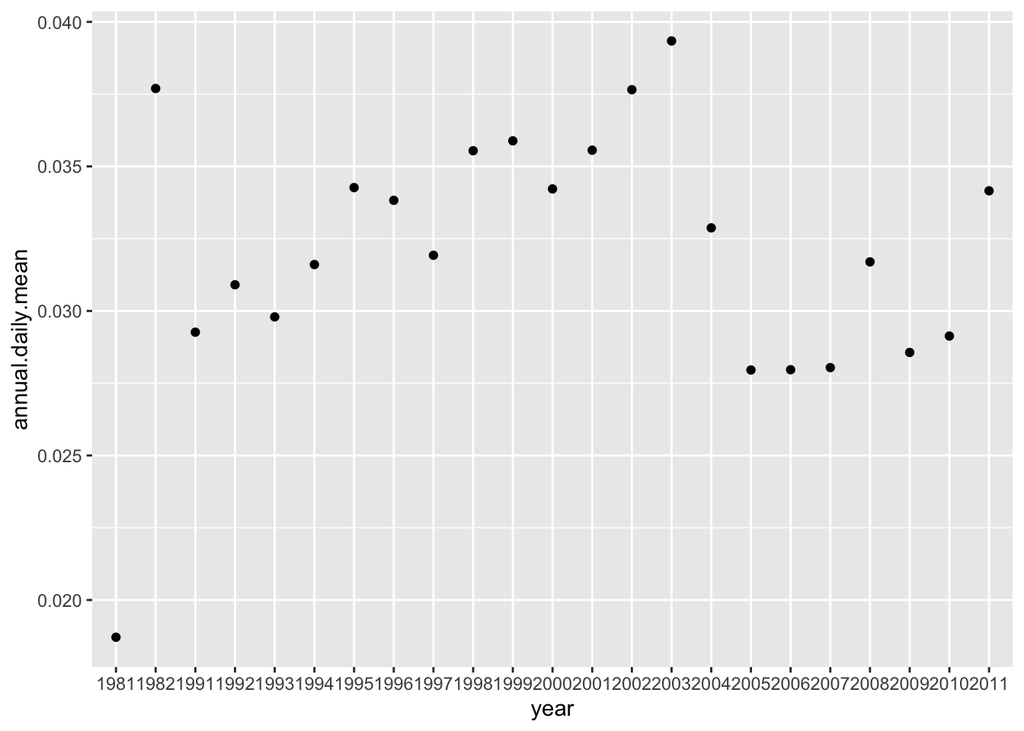

```r
plot_meano3 <- ggplot(ann_mean, aes(y= annual.daily.mean, x= year)) +
  geom_point()

plot_meano3 + geom_smooth(method = "loess", span = 0.5, se= FALSE)
```

**14. Document the long-term and seasonal trends in Merced County daily mean o3 using STL. Note that although the monitoring program aimed at collecting daily samples, there may have been occasional missing days in the record. Any missing values should be imputed using median polish with appropriate monthly or weekly averages.**

```r
#meano3_stl<- stl(smoothmod, span = 0.5)
#Error in stl(smoothed5) : series is not periodic or has less than two periods

#plot(meano3_stl)
```

**Qian chapter 6 Q4

```r
bod.dat <- source("/Users/akandhway/Coursework_Mac/CW_Spring_2020/ES_207/ES207_HW/Homework_8/bodMCMC.s")
bod.dat <- data.frame(Y = c(3.93, 6.8, 9.13, 10.86, 11.72, 12.58, 13.27, 14.23,
    15.83, 16.81, 17.96, 18.45, 19.01, 19.58, 20.08, 20.49, NA,
    22.46), Time = c(5, 10, 15, 20, 25, 30, 35, 40, 50, 60, 70, 80,
    90, 100, 110, 120, 140, 180))
bod.dat
```

```
##        Y Time
## 1   3.93    5
## 2   6.80   10
## 3   9.13   15
## 4  10.86   20
## 5  11.72   25
## 6  12.58   30
## 7  13.27   35
## 8  14.23   40
## 9  15.83   50
## 10 16.81   60
## 11 17.96   70
## 12 18.45   80
## 13 19.01   90
## 14 19.58  100
## 15 20.08  110
## 16 20.49  120
## 17    NA  140
## 18 22.46  180
```

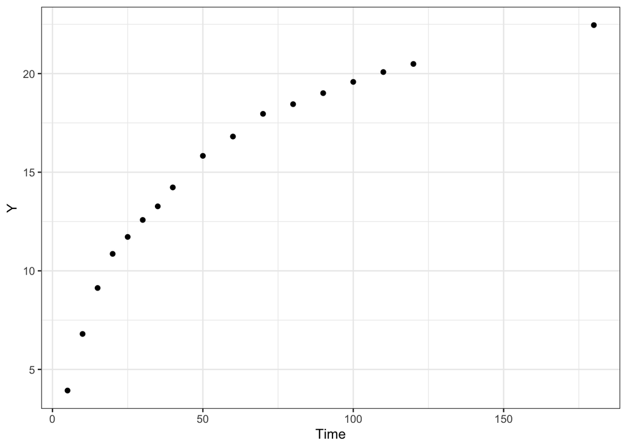

```r
ggplot (bod.dat, aes(x = Time, y = Y)) +
  geom_point() + theme_bw()
```

```r
#mod <- nls(Y ~ A - (A*exp(1-N) - lrc*bod.dat$Time*(1-N))*exp(1/(1-N)), data = bod.dat, start = c(A = 20, lrc = log(0.35), N=2),  na.action())
#Error in nlsModel(formula, mf, start, wts) : singular gradient matrix at initial parameter estimates
```

```r
modbod2 <- nls(Y ~ A*(1-exp(-exp(lrc)*Time)), data = bod.dat,
   start = c(A = 20, lrc = log(.35)))
coef(modbod2)
```

```
##         A       lrc
## 20.626099 -3.439262
```

```r
modbod2
```

```
## Nonlinear regression model
##   model: Y ~ A * (1 - exp(-exp(lrc) * Time))
##    data: bod.dat
##      A    lrc
## 20.626 -3.439
##  residual sum-of-squares: 11.46
##
## Number of iterations to convergence: 7
## Achieved convergence tolerance: 1.834e-06
```